# Rendimiento académico, hábitos cotidianos y herramientas de aprendizaje utilizadas en los estudiantes UTEC que llevaron ciertos cursos de ciencias generales

2023-05-05

# 1 Introducción

## 1.1 Relevancia

La educación superior es un desafío que tienen que superar muchos estudiantes, la transición del colegio a la universidad es un proceso complicado para la mayoría de los nuevos ingresos. A falta de la poca experiencia en la práctica de estudiar de manera autónoma, la carga académica de la educación superior suele ser bastante tediosa en los primeros semestres de la universidad.

Para superar esto, es importante que los estudiantes **aprendan a utilizar herramientas efectivas**. Sin embargo, no todos los estudiantes utilizan las mismas herramientas **ni aprenden de la misma manera**. Algunos prefieren estudiar con libros, diapositivas que son de la asignatura, otros prefieren usar herramientas como videos en Youtube, asesorías personalizadas. Por esto es importante identificar qué herramientas de estudio usan los alumnos y poder **reconocer las debilidades y fortalezas de cada uno.**

De igual manera, podemos dar a conocer qué tipo de herramientas utilizan algunos alumnos en **cursos específicos**, y así recomendar herramientas a los estudiantes de nuevo ingreso para que sepan cómo sobrellevar la carga académica de sus primeros semestres.

## 1.2 Objetivos

## 1.3 Objetivo General

Conocer los hábitos cotidianos de nuestra muestra, analizarlos y relacionarlos con su rendimiento académico y las herramientas que escogen para determinados cursos.

### 1.3.1 Objetivos específicos

- Identificar qué herramientas internas y externas son las más y menos empleadas por los estudiantes en determinados cursos
- Identificar la cantidad de estudiantes autodidactas
- Hallar la cantidad de alumnos que presentan sobrecarga de cursos.
- Dar a conocer las herramientas menos usadas para mejorar el rendimiento académico.

## 1.4 Contexto

Ya que estamos investigando el uso de herramientas de estudio en el periodo universitario, usamos conocimientos de algunas áreas clave relevantes a nuestra investigación. Comenzamos el proyecto **investigando las distintas herramientas de estudio** que se pueden utilizar en la universidad, sus usos, beneficios, y desventajas.

Esto podría incluir aspectos como la eficiencia en el análisis de datos, la visualización de resultados, la reproducibilidad de los estudios, la disponibilidad de recursos y el nivel de satisfacción de cada alumno al usar esta herramienta.

También, investigamos sobre los métodos de estudio usados durante el periodo de estudio y cómo se pueden aplicar estas herramientas en el proceso de estudio. Además, buscamos información sobre las experiencias y opiniones de estudiantes que han utilizado estas herramientas en su trabajo académico. Otro aspecto importante del proyecto fue investigar los **cursos más popularmente difíciles** ya que podían existir ciertos cursos o asignaturas que sean considerados, por los estudiantes, más **desafiantes o exigentes** en diferentes carreras.

Con respecto al uso de los conocimientos en RStudio, hicimos uso sobre la programación en R, el análisis estadístico, visualización de datos, reproducibilidad y documentación, gestión de paquetes y control de versiones, y uso de distintos tipos de gráficos.

# 2 Datos

## 2.1 Recolección de datos

La recolección de datos se realizó a través de un muestro aleatorio simple empleando como instrumento la encuesta realizada mediante Google forms. Se consideraron 24 variables dirigidas a estudiantes de UTEC, las preguntas fueron creadas orientadas a conocer sus hábitos cotidianos y su satisfacción con ciertas herramientas de fácil comprensión. De igual manera, en el forms aplicamos mecanismos de control de respuestas para minimizar errores en las respuestas.

## 2.2 Población, muestra y muestreo

[output not shown]

## 2.3 Variables

### 2.3.1 Numéricas Continuas

| Variable | Tipo de Variable | Descripción |
| --- | --- | --- |
| Promedio Ponderado | Numérica Continua | Número real entre 0 y 20, indica el promedio ponderado del alumno |
| Minutos diarios dedicados a actividades físicas en el periodo académico | Numérica Continua | Número real positivo entre 0 y 500, indica la cantidad de minutos diarios invertidos en Actividades Físicas en durante el periodo académico |
| Minutos diarios dedicados a actividades físicas en vacaciones | Numérica Continua | Número real positivo entre 0 y 500, indica la cantidad de minutos diarios invertidos en Actividades Físicas en durante el periodo de vacaciones |
| Horas diarios estudiando fuera de la universidad | Numérica Continua | Número real positivo entre 0 y 8, indica la cantidad de minutos diarios invertidos en el estudio por su propia cuenta |

### 2.3.2 Numéricas Discretas

| Variable | Tipo de Variable | Descripción |
| --- | --- | --- |
| Edad | Numérica Discreta | Número entero positivo mayor a 0, indica la edad del estudiante |
| Cantidad de cursos que lleva por ciclo normalmente | Numérica Discreta | Número entero positivo, indica la cantidad de cursos que lleva en un ciclo |
| Cantidad de horas diarias que duerme en el periodo académico | Numérica Discreta | Número entero positivo, indica la cantidad de horas diarias que duerme el estudiante |
| Cantidad de horas dedicadas semanalmente en un curso escogido | Numérica Discreta | Número entero positivo, indica la cantidad de horas semanales a un curso en específico |

### 2.3.3 Categóricas Nominales

| Variable | Tipo de Variable | Descripción |
| --- | --- | --- |
| Sexo | Categórica Nominal | Indica el sexo del estudiante, Hombre o Mujer |
| Carrera | Categórica Nominal | Indica la carrera universitaria del estudiante |
| Curso a escoger | Categórica Nominal | Existen 3 opciones a escoger, cursos que queremos evaluar los cuales son: cálculo I, programación o introducción a la mecánica |
| Principal factor que dificulta el aprendizaje | Categórica Nominal | Podría ser: Falta de tiempo por responsabilidades externas, Escasa de motivación o interés por aprender el curso, Falta de tiempo por llevar demasiados cursos, Escasos recursos |
| Tipos de Herramientas externas e internas | Categórica Nominal | Las herramientas internas son proporcionadas por la universidad como parte del programa de estudios. Algunos tipos de estas son; grabaciones, pdfs, asesorías, libros que se encuentran en UTEC. Las her… |
| Herramientas sugeridas, no mencionadas en el estudio | Categórica Nominal | Sugerencias de herramientas por parte de los estudiantes |

### 2.3.4 Categóricas Ordinales

| Variable | Tipo de Variable | Descripción |
| --- | --- | --- |
| Nivel de Estrés en el periodo académico | Categórica Ordinal | Indica que tanto estrés siente en un nivel del 1 al 5 |
| Nivel de Ansiedad en el periodo académico | Categórica Ordinal | Indica que tanta ansiedad siente en un nivel del 1 al 5 |
| Nivel de Depresión en el periodo académico | Categórica Ordinal | Indica que tan deprimido se siente en un nivel del 1 al 5 |
| Nivel de Satisfacción con diferentes herramientas | Categórica Ordinal | Qué tan satisfecho se siente con ciertas herramientas de estudio |

# 3 Limpieza de base de datos

Para este proyecto se utilizaron las siguientes librerías:

```r
library(readr)
library(dplyr)
library(ggplot2)
library(knitr)
library(tidyr)
library(tidyverse)
library(scales)
library(ggthemes)
library(ggmosaic)
```

- **readr** se utilizó para poder leer el archivo .csv de la data de nuestra encuesta
- **dplyr** se utilizó para manejar la data de una manera más eficiente, utilizando varios comandos para limpiar y modificar las filas y columnas de nuestro data frame
- **ggplot2** se utilizó para la creación de nuestra gráficos descriptivos, destacamos el uso de la función de *facet-wrap* para la unión de gráficos acoplados
1. Comenzamos leyendo la data con la función **read_csv**

```r
DF <- read_csv("data.csv")
```

2. Luego, eliminamos algunas columnas que no son necesarias en nuestro estudio

```r
DF <- subset(DF, select = -`Marca temporal`)
DF <- subset(DF, select = -`Puntuación`)
DF <- subset(DF, select = -`Correo UTEC`)
```

3. Para un manejo eficiente de la data modificamos los nombres de las columnas (variables) con nombres más adecuados

```r
names(DF)[1]<-"Carrera"
names(DF)[3]<-"Edad"
names(DF)[4]<-"cursos_Por_Ciclo"
names(DF)[5]<-"Nivel_de_Estres"
names(DF)[6]<-"Nivel_de_Ansiedad"
names(DF)[7]<-"Nivel_de_Depresion"
names(DF)[8]<-"Horas_diarias_Sueño"
names(DF)[9]<-"Promedio_ponderado_CicloPasado"
names(DF)[10]<-"Mins_AFisic_PAcademico"
names(DF)[11]<-"Mins_AFisic_Vacaciones"
names(DF)[12]<-"AFisic_Animo_posi"
names(DF)[13]<-"Mins_diarios_estudio_Fuera"
names(DF)[14]<-"Curso_seleccionado"
names(DF)[15]<-"Horas_invertidas_cSelec"
names(DF)[16]<-"Factor_dificultad_Aprendizaje"
names(DF)[17]<-"Satisfaccion_PDF"
names(DF)[18]<-"Satisfaccion_Grabaciones"
names(DF)[19]<-"Satisfaccion_Asesorias"
names(DF)[20]<-"Satisfaccion_LibrosUTEC"
names(DF)[21]<-"Satisfaccion_GrupEstudio"
names(DF)[22]<-"Satisfaccion_Youtube"
names(DF)[23]<-"Satisfaccion_LibrosExternos"
names(DF)[24]<-"Otras_Herramientas"
```

### 3.0.1 Observacion para la limpieza

Debido a que se pusieron varias restricciones en el forms para las respuestas, no tuvimos que limpiar muchos datos.

- Para un mejor manejo de los datos se ha creado un sub-dataframe llamado *dataCurso* para poder trabajar con ciertos parámetros

```r
dataCurso <- data.frame(
  pdf = c(DF$Satisfaccion_PDF),
  grabs = c(DF$Satisfaccion_Grabaciones),
  aseso = c(DF$Satisfaccion_Asesorias),
  libUtec = c(DF$Satisfaccion_LibrosUTEC),
  grupoEstudio = c(DF$Satisfaccion_GrupEstudio),
  youtube = c(DF$Satisfaccion_Youtube),
  libExternos = c(DF$Satisfaccion_LibrosExternos),
  cursoSelec = c(DF$Curso_seleccionado),
  hInver = c(DF$Horas_invertidas_cSelec),
  fDificultad = c(DF$Factor_dificultad_Aprendizaje)
)
```

- Se presentaron complicaciones para calcular el promedio de Horas Invertidas por Curso Seleccionado asi que se decidió trabajarlo con la frecuencia de horas que presentaba cada curso y luego modificarlo de tal manera en la que el manejo de los datos sean eficientes y se pueda calcular mejor.

```r
hInverCurso<-table(dataCurso$hInver, dataCurso$cursoSelec)
hInverCurso <- as.data.frame(hInverCurso)
hInverCurso<- hInverCurso %>%
  pivot_wider(
    names_from = "Var2",
    values_from = "Freq")
```

- Acotación: Dentro de nuestro código en el .rmd hemos hecho diferentes modificaciones, creado sub-data frames para poder tener un mejor manejo de los datos. Estos se pueden presenciar en gráficos como los heatmaps realizados y algunas tablas. Igualmente dentro de cada chunk para ejecutar los gráficos se ven detallados los pasos seguidos para llegar al resultado esperado.

# 4 Análisis descriptivo

## 4.1 Análisis Univariado

### 4.1.1 Carrera

#### 4.1.1.1 Gráfico 1 - Distribución por carreras

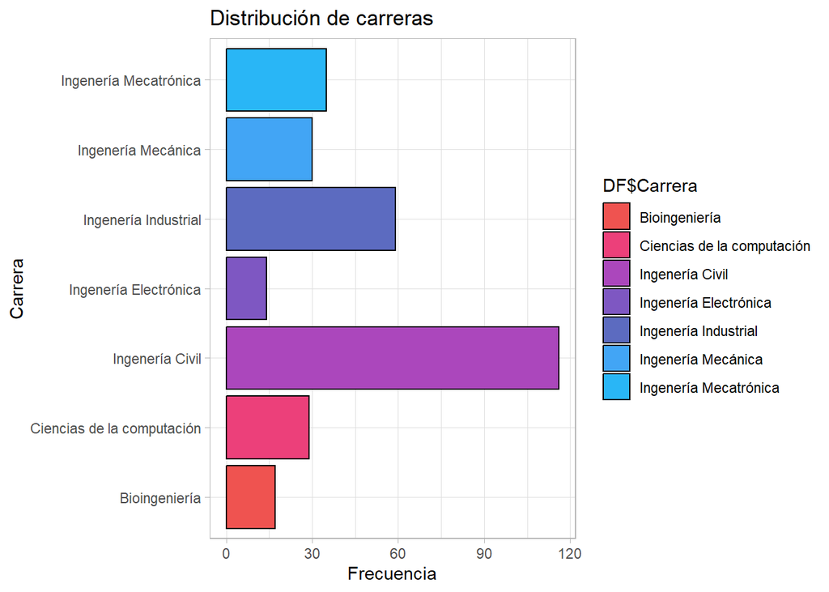

#### 4.1.1.2 Tabla 1 - Porcentaje por carreras

Porcentajes por carrera

| Carrera | Alumnos | Porcentaje |
| --- | --- | --- |
| Bioingeniería | 17 | 0.06 |
| Ciencias de la computación | 29 | 0.10 |
| Ingenería Civil | 116 | 0.39 |
| Ingenería Electrónica | 14 | 0.05 |
| Ingenería Industrial | 59 | 0.20 |
| Ingenería Mecatrónica | 35 | 0.12 |
| Ingenería Mecánica | 30 | 0.10 |

##### 4.1.1.2.1 Tabla de Interpretación 1 - Variable Carrera

| Descriptores | Valores e Interpretación |
| --- | --- |
| Moda | En nuestra muestra podemos apreciar que la carrera de Ingeniería Civil es la que más predomina con un total de 116 persona y abarca un 39% de la muestra |

### 4.1.2 Edad

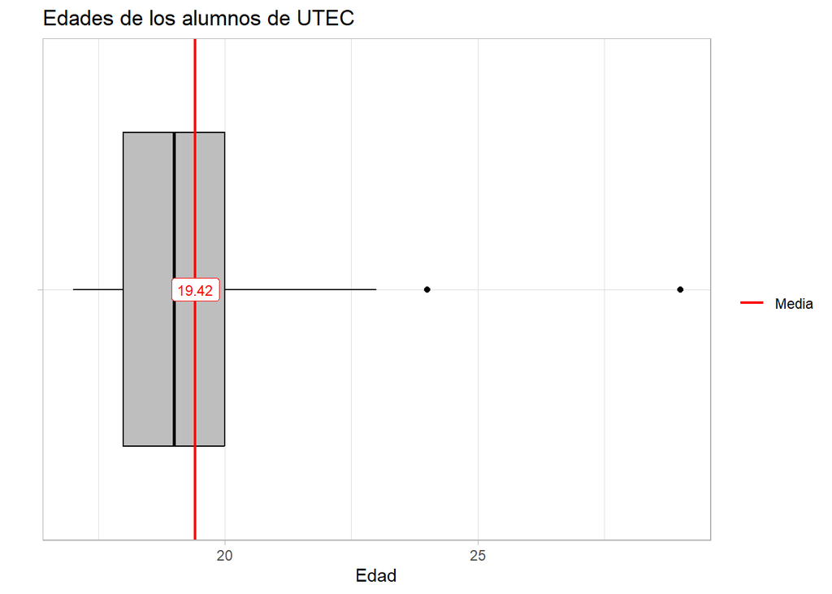

```r
table(DF$Edad)
```

```
##
## 17 18 19 20 21 22 23 24 29
## 26 65 87 76 19 11  9  2  5
```

| Descriptor | Resultado | Interpretacion |
| --- | --- | --- |
| Cuartil 3 | 20.000 | El 75% de los datos son menores a 20 |
| Cuartil 1 | 18.000 | El 25% de los datos son menores a 18 |
| Rango Intercuartil | 2.000 | El 50% de los datos se encuentra entre 20 años y 18 años |
| Mediana | 19.000 | El 50% de los datos son menores o iguales a 19 años |
| Varianza | 3.549 | Una varianza de 3.55 sugiere que las edades de los alumnos en la muestra tienden a estar bastante cercanas a la media. Esto implica que hay una menor variabilidad o dispersión en las edades observadas |
| Desviación Estándar | 1.884 | Una desviación estándar de 1.88 indica que, en promedio, los valores individuales se alejan aproximadamente 1.88 unidades de la media de la edad |
| Coeficiente de variación | 9.700 | Un coeficiente de variación del 9.7% indica que la variabilidad en las edades es baja en comparación con la media de las edades. Esto sugiere que las edades de los alumnos en la muestra están relativa… |

### 4.1.3 Minutos diarios

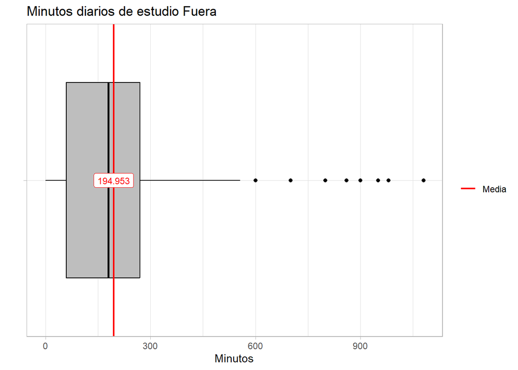

- En esta table podremos ver los diferentes valores de los minutos de estudio

```r
table(DF$Mins_diarios_estudio_Fuera)
```

```
##
##    0    9   20   23   25   30   40   50   60   90  100  120  140  150  160  170
##   36    1    2    1    1    1    5    5   39    4    1   39    3    3    3    2
##  180  190  198  200  205  210  220  240  260  300  320  350  360  400  420  460
##   28    1    1    7    1    5    1   25   10   27    4    1   20    5    1    1
##  500  556  600  700  800  860  900  950  980 1080
##    1    1    4    3    1    1    2    1    1    1
```

| Descriptor | Resultado | Interpretacion |
| --- | --- | --- |
| Mínimo | 0.000 | El minimo de los minutos es 0, tenemos algunos alumnos que no estudian fuera de la universidad |
| Máximo | 1080.000 | La máxima cantidad de minutos presentada fue de 1080 minutos por una sola persona |
| Cuartil 3 | 270.000 | El 75% de los datos son menores a 270 minutos |
| Cuartil 1 | 60.000 | El 25% de los datos son menores a 60 minutos |
| Rango Intercuartil | 210.000 | El 50% de los datos se encuentra entre 270 minutos y 60 minutos, lo cual nos daría un RIQ igual a 210 |
| Media | 194.953 | En promedio, los alumnos en la muestra estudian 194.953 minutos |
| Mediana | 180.000 | El 50% de los datos son menores o iguales a 180 minutos |
| Desviación Estándar | 178.776 | Dado que los valores de los minutos de estudio van desde 0 hasta 1080, una desviación estándar de 178.776 sugiere que los minutos de estudio fuera de la universidad varían ampliamente en la muestra. E… |
| Coeficiente de variación | 91.700 | Un coeficiente de variación del 91.7% implica que la dispersión de los minutos de estudio fuera de la universidad es muy amplia en relación con la media. Esto sugiere que hay una gran variabilidad en … |

### 4.1.4 Horas diarias de Sueño

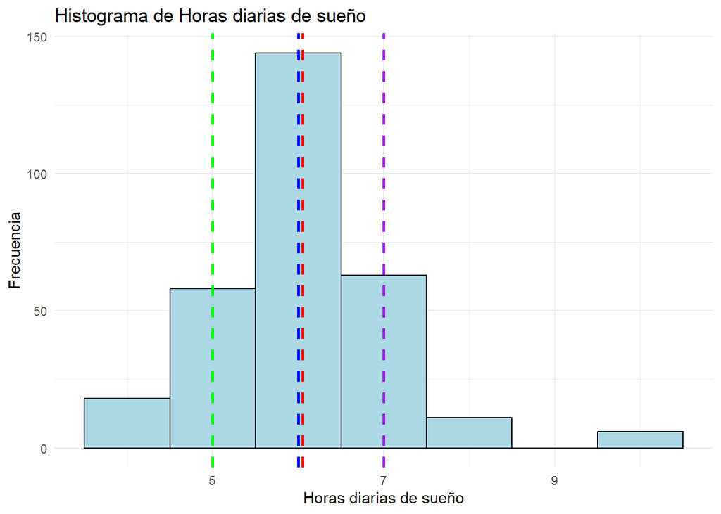

- Lo aconsejable según muchos expertos es al menos 8 horas de sueño reparador para conseguir estar descansado y con la mente activa para el estudio. (Marcos Nebreda López, 2022) Sin embargo, según nuestros resultados, la frecuencia de horas de sueño más alta es de 6 horas diarias. Extraído de: [campus.training.es](https://www.campustraining.es/noticias/cuantas-horas-hay-dormir-para-estudiar/#:~:text=Por%20ello%2C%20lo%20aconsejable%20seg%C3%BAn,mente%20activa%20para%20el%20estudio)

[output not shown]

## 4.2 Análisis Bivariado

### 4.2.1 Horas invertidas semanalmente a un curso por Curso Seleccionado

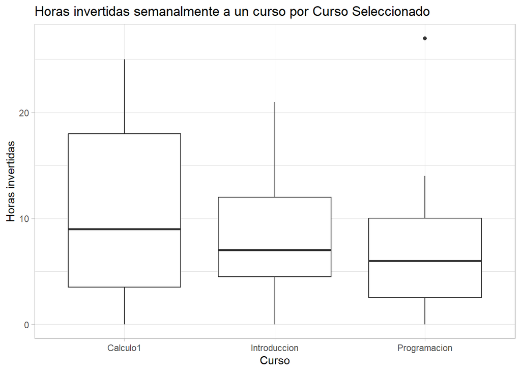

| Descriptores | Calculo 1 | Introduccion a mecánica | Programación 1 |
| --- | --- | --- | --- |
| Mínimo | 0.0000000 | 0.000000 | 0.000000 |
| Máximo | 25.0000000 | 21.000000 | 27.000000 |
| Cuartil 3 | 18.0000000 | 12.000000 | 10.000000 |
| Cuartil 1 | 3.5000000 | 4.500000 | 2.500000 |
| IQR | 14.5000000 | 7.500000 | 7.500000 |
| Media | 11.2727273 | 8.454546 | 7.545454 |
| Mediana | 9.0000000 | 7.000000 | 6.000000 |
| Varianza | 86.6181818 | 46.072727 | 61.872727 |
| Desviación estándar | 9.3068889 | 6.787689 | 7.865922 |
| Coeficiente de Variación | 0.8256111 | 0.802845 | 1.042472 |

**Mínimo:**

El valor mínimo de horas en la de la tabla es 0.De esto se puede inferir que existen alumnos que no le toman importancia al curso o dominan el curso

- Los distintos resultados de la varianza, la desviación estándar y el coeficiente de variación, pueden ser relevantes a factores como la dificultad del curso, la carga de trabajo, entre otros.

### 4.2.2 Factor de dificultad de Aprendizaje por Curso seleccionado

- En este análisis bivariado vemos la interacción entre dos variables categóricas nominales, el factor de dificultad de aprendizaje y el curso seleccionado. Dentro de los factores de dificultad de aprendizaje tenemos las siguientes 3 opciones:

```r
unique(DF$Factor_dificultad_Aprendizaje)
```

```
## [1] "Escasa de motivación o interés por aprender el curso."
## [2] "Falta de tiempo por llevar demasiados cursos."
## [3] "Falta de tiempo por responsabilidadades externas( en lo personal, familiar ,laboral, etc)"
```

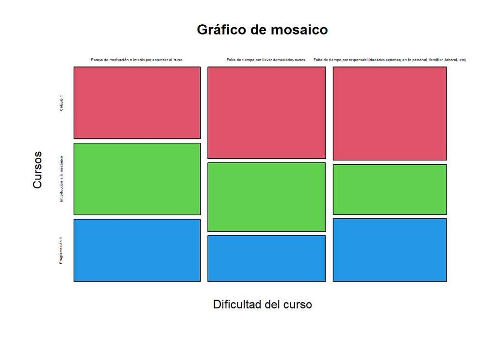

```r
table(DF$Curso_seleccionado, DF$Factor_dificultad_Aprendizaje)
```

```
##
##                              Escasa de motivación o interés por aprender el curso.
##   Calculo 1                                                                     37
##   Introduccion a la mecánica                                                    37
##   Programación 1                                                                32
##
##                              Falta de tiempo por llevar demasiados cursos.
##   Calculo 1                                                             44
##   Introduccion a la mecánica                                            33
##   Programación 1                                                        22
##
##                              Falta de tiempo por responsabilidadades externas( en lo personal, familiar ,laboral, etc)
##   Calculo 1                                                                                                         43
##   Introduccion a la mecánica                                                                                        23
##   Programación 1                                                                                                    29
```

### 4.2.3 Nivel de Satisfacción con cada herramienta por curso

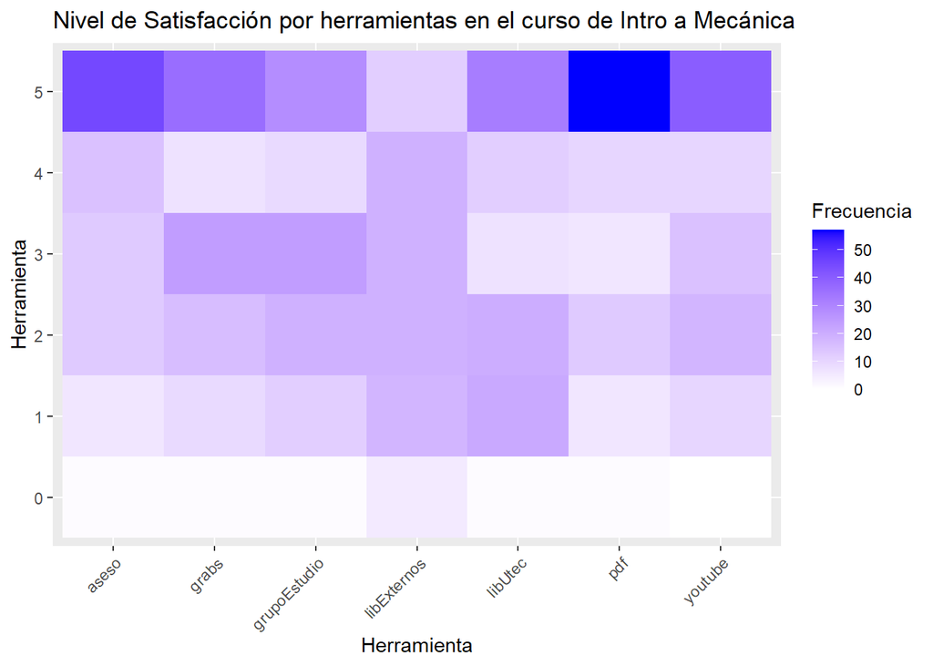

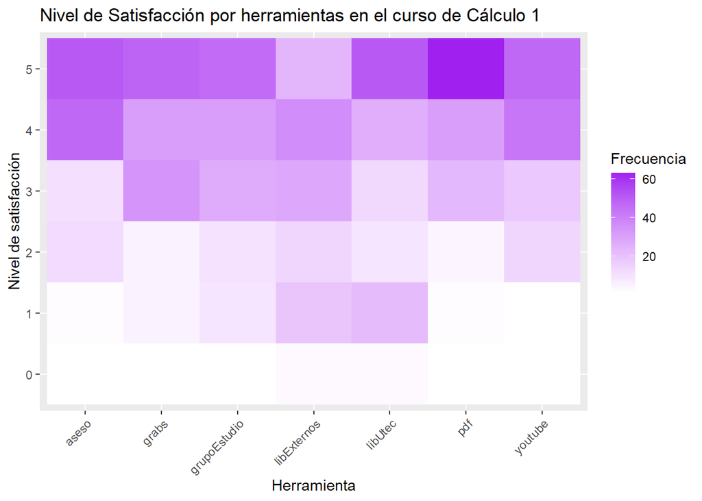

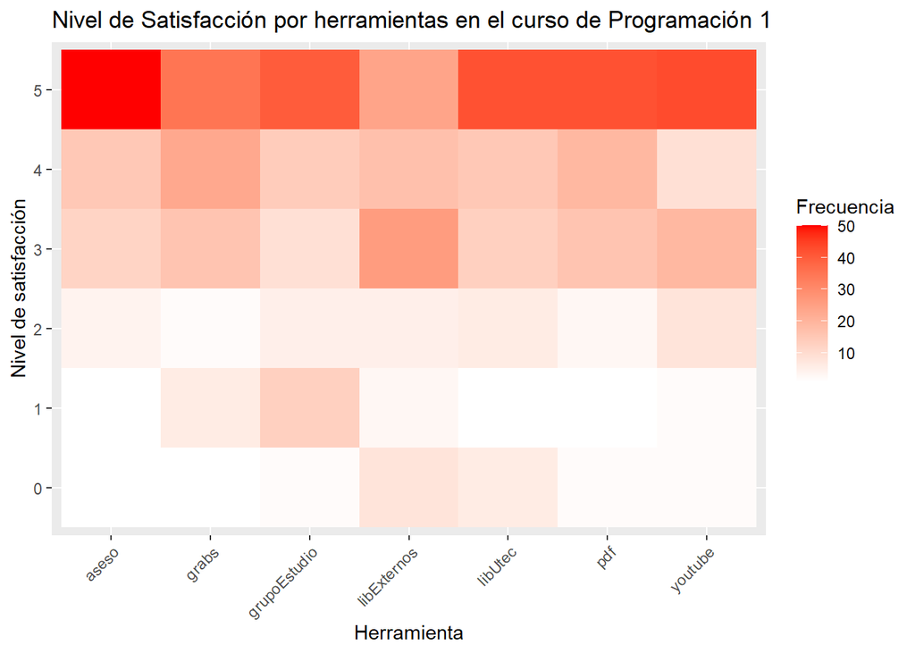

- Usamos el gráfico heatmap para visualizar patrones de frecuencia del nivel de satisfacción de cada herramienta para los tres cursos, Cálculo 1, Introducción a la Mecánica, y Programación 1. En el caso del curso de **Cálculo 1**, la mayor frecuencia del nivel de satisfacción es para los **PDFs con (50.81%, 63 de 124 personas)**. Para **Introducción a la Mecánica**, la herramienta con que muestra la mayor frecuencia de nivel de satisfacción también son los **PDFs con (61.29%, 57 de 93 personas)**. y finalmente para Programación 1, la mayor frecuencia del nivel de satisfacción es para las **Asesorías con (60.24%, 50 de 83 personas)**. Los resultados demuestran que las herramientas con mayor nivel de satisfacción son los PDFs y las asesorías. Esto puede ser índice de que para estos cursos estas herramientas son con la que los alumnos están más satisfechos.

### 4.2.4 Polígono de Frecuencias comparando Niveles de Estrés, Ansiedad y Depresión

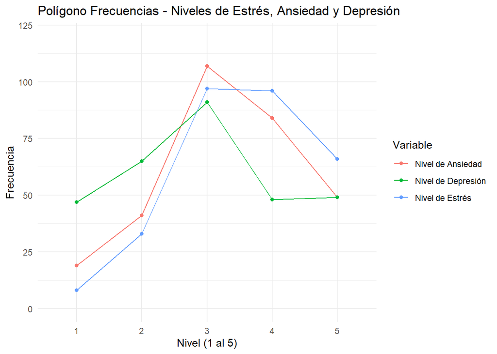

- Usamos un gráfico polígono para mostrar la frecuencia del nivel de estrés, del nivel de ansiedad, y del nivel de depresión. Se puede observar que en los niveles más altos **(4 y 5)** predomina el nivel de estrés y ansiedad. Sin embargo, en donde se acumula más los datos es en el **3** en donde podemos ver que tanto Ansiedad, Estrés y Depresión alcanzan su punto más alto